# Exogenous Forcing in exDE

December 08, 2023

`~/exDE/exDE.Rmd`

HUB – Roadmap – Library – exDE

## $\odot$

To implement exogenous forcing in `exDE`, we were faced with a design question about how much structure was needed. We wanted to build in enough structure so that it would be clear *how* to add exogenous forcing. We also discovered that at least *some* structure would be required. Since some variables must be set before others, we wanted to order the function calls to avoid conflicts.

- `Forcing` – a longer discussion of `exDE` design for exogenous forcing

## Forcing

### $\oplus$

### Scaffold

- `Abiotic`
  - `Weather`
  - `Hydrology`
- `Shock`
- `Control`
  - `MassMedical`
  - `Clinic`
  - `VectorControl`
- `Behavior`
- `Visitors`
- `VectorControlEffects`
- `Resources`
- `EIP`
- `MBionomics`
- `LBionomics`
- `VectorControlEffectSizes`

## Long Walk

### $\oplus$

### $\cal W$ - Weather

We start by setting up a model:

```r
library(exDE)
model <- xde_setup("weather", MYZname = "GeRM")
```

To configure exogenous forcing by weather, it is necessary to do four things:

1. Turn on abiotic forcing
2. Turn on weather
3. Configure the functions that compute variables describing weather.
4. Configure the functions that compute the effects of variables on various parameters.

**Step 1**

```r
model = setup_abiotic_forced(model)
```

The function `Abiotic(t, pars)` is an `S3` function that dispatches on `pars$ABIOTIC`. By default, `ABIOTIC` is an empty list and `class(ABIOTIC) = NULL`, so it has no effect. The first step in setting up forcing is to set `class(ABIOTIC) <- "forced"`. Now the function `Abiotic.forced(t, pars)` calls two functions:

- `Weather(t,pars)`
- `Hydrology(t, pars)`

**Step 2**

```r
model = setup_weather_forced(model)
```

The function `Weather(t, pars)` is an `S3` function that dispatches on `pars$WEATHER`. By default, `WEATHER` is an empty list and `class(WEATHER) = NULL`, so it has no effect. The first step in setting up forcing is to set `class(WEATHER) <- "forced"`. Now the function `Weather.forced(t, pars)` calls three functions:

- `Rainfall(t,pars)` is an `S3` function that dispatches on `pars$RAINFALL` and by default, `class(RAINFALL) = NULL`
- `Temperature(t,pars)` is an `S3` function that dispatches on `pars$TEMPERATURE` and by default, `class(TEMPERATURE]) = NULL`
- `Relative_Humidity(t, pars)` is an `S3` function that dispatches on `pars$HUMIDITY` and by default, `class(HUMIDITY) = NULL`

**Step 3**

Now we need to set up a function that computes `Temperature.` Here, we set up a sin function:
$$T(t) = 25+ 5 \sin(2\pi t/365)$$

```r
Temperature.eg= function(t, pars){
  pars$temperature =  25 + 5*sin(2*pi*t/365)
  return(pars)
}
```

Now we set:

```r
class(model$TEMPERATURE) <- "eg"
```

**Step 4**
$$\tau(t) =
\frac{1}{0.000112 T (T-15.384) \sqrt{35-T}}$$
so
$$\frac{d\tau(t)}{dt} =
-\frac{0.000112\left[-\left(T^2-15.384T\right) \left(35-T\right)^{-1/2}
+ \sqrt{35-T} \left(2T - 15.384\right)\right]}{\left(0.000112 T
(T-15.384) \sqrt{35-T}\right)^2}$$

We need to write the EIP as a function of temperature:

```r
dEIPdt.eg = function(t, pars){
  T = pars$temperature
  1-0.000112*(-(T^2-15.384*T)* (35-T)^(-1/2) + sqrt(35-T)* (2*T - 15.384))/ ((0.000112*T*(T-15.384)*sqrt(35-T)))^2
  return(pars)
}
```

```r
EIP.eg = function(t, pars){
  T = pars$temperature
  pars$MYZpar$eip <- 1/(0.000112*T*(T-15.384)*sqrt(35-T))
  return(pars)
}
```

```r
EIPmod = list(name = "eg")
class(EIPmod) <- "eg"
```

```r
model$EIPmod = EIPmod
```

To visualize what is happening, we can use these functions without exDE. First, we plot temperature by time of year:

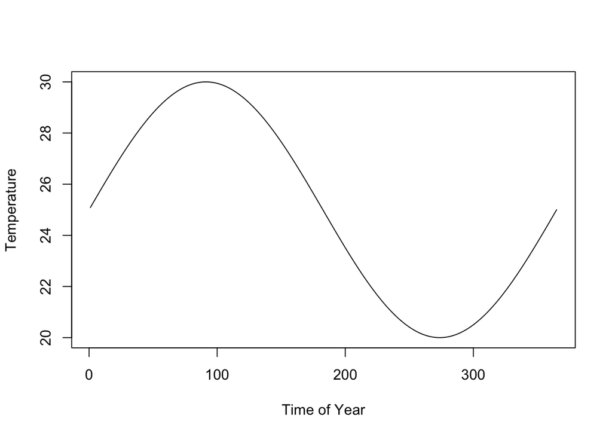

```r
tt=1:365
T = Temperature.eg(tt,list())$temperature
plot(tt, T, type = "l", xlab = "Time of Year", ylab = "Temperature")
```

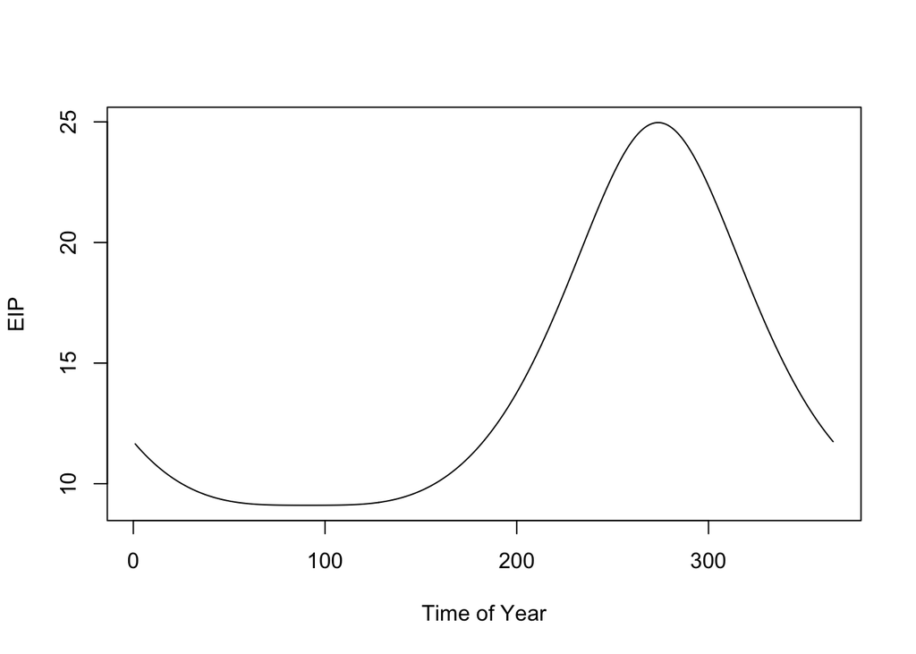

```r
tt=1:365
pars = list(temperature=T, MYZpar=list())
eip = EIP.eg(tt,pars)$MYZpar$eip
plot(tt, eip, type = "l", xlab = "Time of Year", ylab = "EIP")
```

```r
model <- xde_stable_orbit(model)
```

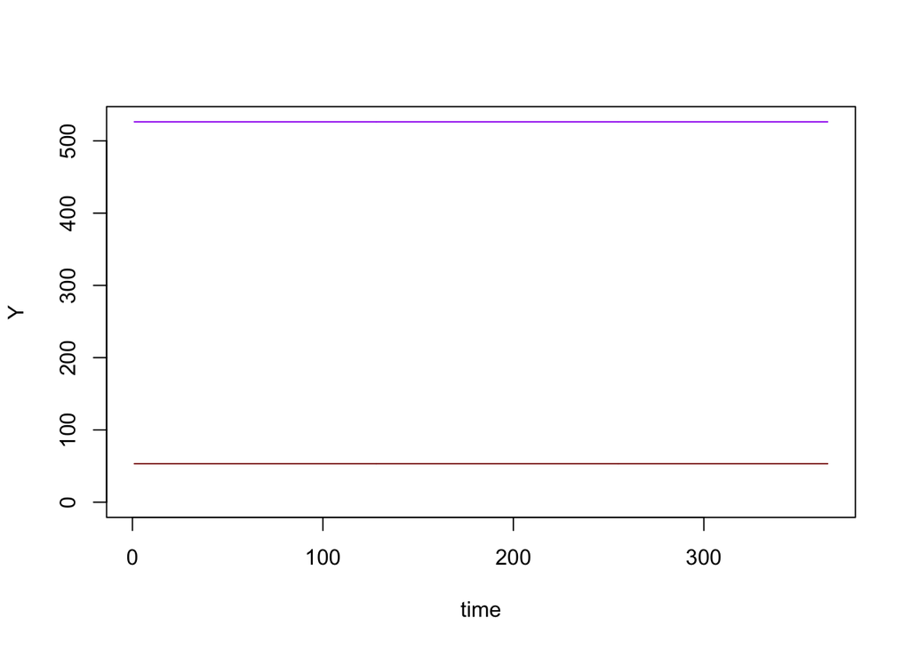

```r
with(model$outputs$stable_orbits, with(MYZ, {
  plot(time, Y, col = "purple", type = "l", ylim = range(0, Y))
  lines(time, Z, col = "darkred")
}))
```

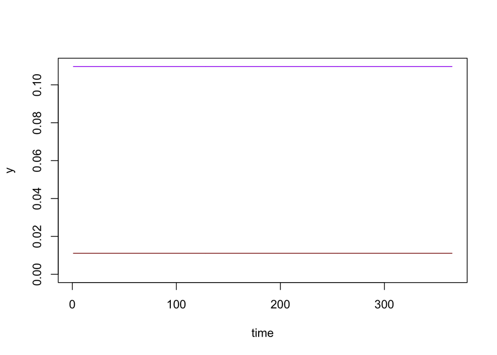

```r
with(model$outputs$stable_orbits, with(MYZ, {
  plot(time, y, col = "purple", type = "l", ylim = range(0,y))
  lines(time, z, col = "darkred")
}))
```

### $\cal V$ - Vector Control

## Setup

### $\oplus$

By default, exogenous forcing is turned off. The list objects defining various kinds of forcing are in a nested hierarchy. If the class of a list object is `null` then there is no need to define anything of the objects it might contain. If a nested `list` objects is defined, then the list that contains it is turned on and set to `forced.`

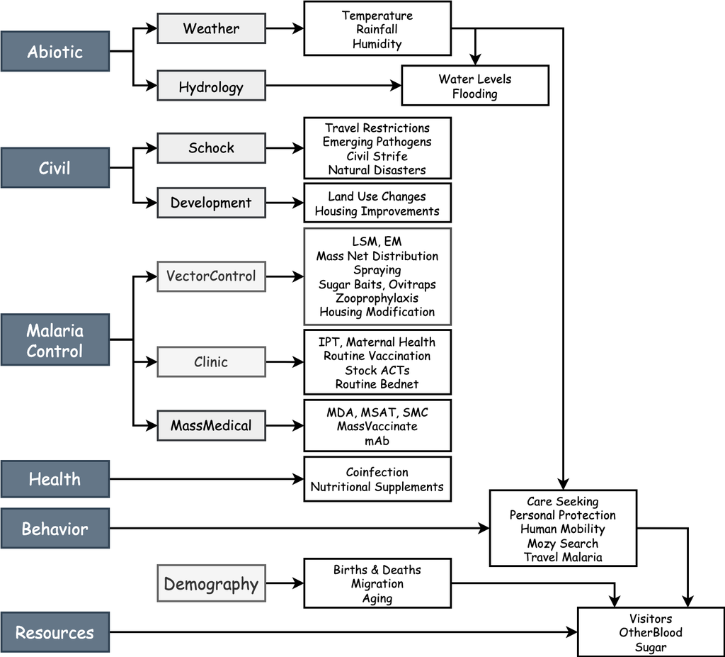

**Figure 1**

## Examples

### $\oplus$

### Weather

### Vector Control

### Hierarchy

- **Abiotic** $\in$ `abiotic.R`
  - **Weather**
    - temperature
    - rainfall
    - humidity
  - **Hydrology**
    - water levels
    - flooding
- **Civil** in `civil.R`
  - **Shock**
    - restrict travel
    - emerging pathogen
    - civil strife
    - natural disaster
  - **Development**
    - permanent housing improvements
    - land use changes
- **Control** in `control.R` describes actions taken by a malaria program that affect the values of **coverage** variables.
  - **MassMedical**
    - mass treat including MDA & MSAT
    - SMC
    - mass vaccinate
    - mass mAb
  - **Clinic**-based distribution
    - case detection
    - IPT
    - maternal health
    - routine vaccination
    - ACT in stock
    - bednet top-up
  - **Vector Control**
    - distribute nets
    - distribute sugar baits
      - ATSB
      - auto-disseminated baits
    - distribute ovitraps
    - mass spray
      - IRS
      - area spray
    - treat habitats
    - zooprophylaxis
    - endectocides
    - improve houses
- **Resources** in `resources`.R`
  - Availability of blood
    - Resident humans
    - Visiting humans
    - Other blood
  - Availability of aquatic habitats
    - Traps
    - Natural Habitats
  - Availability of sugar sources
    - Baits
    - Natural Sugar Sources
  - Availability of resting sites

### Implementation

The function `make_parameters_xde()` gets called to create the `list` that defines a model.

```r
  pars <- setup_exogenous_null(pars)
  pars <- setup_humanbehavior_null(pars)
  pars <- setup_resources_null(pars)
  pars <- setup_vc_null(pars)
  pars <- setup_visitors_null(pars)
  pars <- setup_travel_null(pars)
```